# Regresión Logística y Descenso del Gradiente en Python

## CUNEF - Colegio Universitario De Estudios Financieros

### 13-11-2020

[figure not shown]

# Tabla de contenidos

## Objetivo

El objetivo del trabajo es programar el descenso del gradiente en base al archivo de datos facilitado previamente. Importante el mantenimiento de una estructura de repositorio como hemos estudiado en clase incluyendo un pequeño análisis exploratorio de los datos, histogramas, definición del coste y gradiente, convergencia de $J(\theta)$ y un estudio del descenso de regresión logística y descenso de gradiente en Python.

## Librerías

Importación de librerías necesarias para el análisis.

```python
import numpy as np
import matplotlib.pyplot as plt
import seaborn as sns
import pandas as pd
plt.style.use("ggplot")
%matplotlib inline
```

## Carga de Datos

Exportación del archivo de datos facilitado en clase.

```python
data_raw = pd.read_csv("./data/01_raw.csv")
data_raw.head() # primeras 5 filas
```

|  | score-1 | score-2 | label |
| --- | --- | --- | --- |
| 0 | 34.623660 | 78.024693 | 0 |
| 1 | 30.286711 | 43.894998 | 0 |
| 2 | 35.847409 | 72.902198 | 0 |
| 3 | 60.182599 | 86.308552 | 1 |
| 4 | 79.032736 | 75.344376 | 1 |

## Análisis Exploratorio

Muestras recogidas durante el proceso de investigación.

```python
data_raw.info() # info data
```

```
<class 'pandas.core.frame.DataFrame'>
RangeIndex: 100 entries, 0 to 99
Data columns (total 3 columns):
 #   Column   Non-Null Count  Dtype
---  ------   --------------  -----
 0   score-1  100 non-null    float64
 1   score-2  100 non-null    float64
 2   label    100 non-null    int64
dtypes: float64(2), int64(1)
memory usage: 2.5 KB
```

```python
scores = data_raw[['score-1', 'score-2']].values # divisón en tablas distintas
results = data_raw['label'].values # una tabla esta el score-1 y score-2 y la otra el resultado
```

```python
data_raw.describe() # descripcion data
```

|  | score-1 | score-2 | label |
| --- | --- | --- | --- |
| count | 100.000000 | 100.000000 | 100.000000 |
| mean | 65.644274 | 66.221998 | 0.600000 |
| std | 19.458222 | 18.582783 | 0.492366 |
| min | 30.058822 | 30.603263 | 0.000000 |
| 25% | 50.919511 | 48.179205 | 0.000000 |
| 50% | 67.032988 | 67.682381 | 1.000000 |
| 75% | 80.212529 | 79.360605 | 1.000000 |
| max | 99.827858 | 98.869436 | 1.000000 |

```python
pd.DataFrame(data_raw.isna().sum(),columns = ['Valores NaN']) # muestra los valores NaN, 0 valores
```

|  | Valores NaN |
| --- | --- |
| score-1 | 0 |
| score-2 | 0 |
| label | 0 |

```python
data_raw.shape # El dataset tiene 100 filas y 3 columnas
```

```
(100, 3)
```

```python
data_raw.index # indice que empieza en 0, acaba en 100 y va de 1 en 1.
```

```
RangeIndex(start=0, stop=100, step=1)
```

## Histogramas

Histograma de la primera columna llamada Score-1.

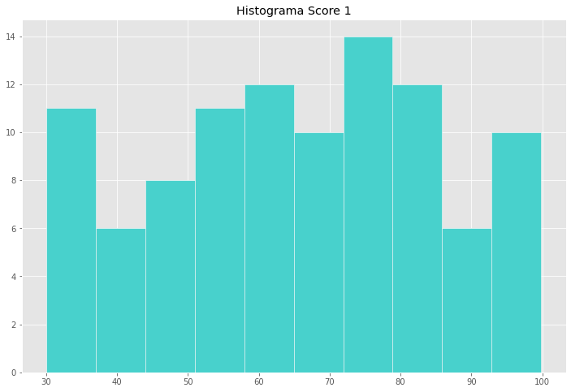

```python
plt.hist(data_raw['score-1'], edgecolor = 'snow', color= 'mediumturquoise' )
plt.title('Histograma Score 1')
plt.grid(True)
```

Histograma de la segunda columna llamada Score-2

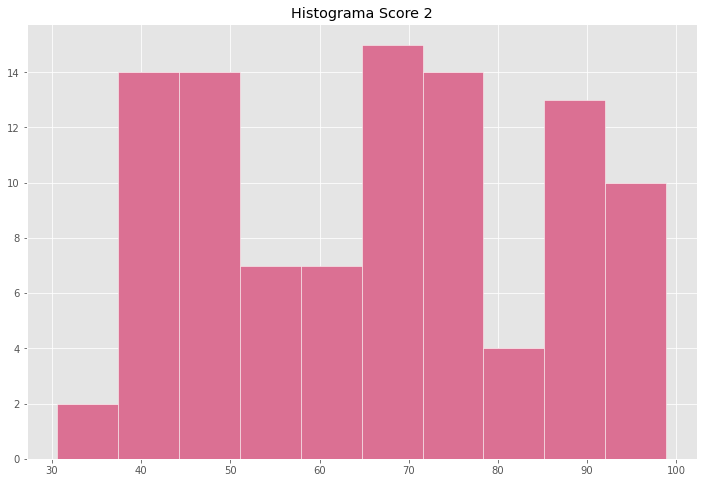

```python
plt.hist(data_raw['score-2'], edgecolor = 'snow', color = 'palevioletred')
plt.title('Histograma Score 2')
plt.grid(True)
```

La diferencia entre los dos histogramas es que en el histograma de Score 2 muestra una distribución de las notas más extrema que las del Score 1, donde las notas son más céntricas.

## Matríz de correlación

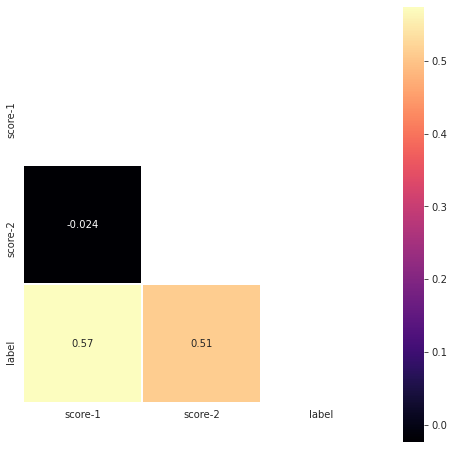

```python
corr = data_raw.corr()
mask = np.zeros_like(corr)
mask[np.triu_indices_from(mask)] = True
with sns.axes_style("white"):
    f, ax = plt.subplots(figsize=(8, 8))
    ax = sns.heatmap(corr,mask=mask,square=True,linewidths=.8,cmap="magma",annot=True)
```

Una correlación negativa entre los dos scores. Y una correlación positiva de los dos scores con el label, resultado.

## Definición Función Logística Sigmoid

[figure not shown]

```python
def logistic_function(x):    # función logística Sigmoid
    return 1/ (1 + np.exp(-x))
```

```python
logistic_function(0) # 0.5 resultado
```

```
0.5
```

Es una función delimitada que se define para todos los valores de entrada real y tiene un derivado no negativo en cada punto y un punto de inflexión, refiriéndose al mismo objeto.

## Función de Coste y Gradiente

[figure not shown]

El coste de función es una relación entre el nivel de producción y el coste económico que implica generarlo.

El gradiente es una función de valor vectorial y representa la pendiente de la línea tangente a la gráfica de una función.

```python
def compute_cost(theta, x, y):
    m = len(y) # numero total de observaciones
    y_pred = logistic_function(np.dot(x , theta)) # predicción de y, que es el producto de X y theta
    error = (y * np.log(y_pred)) + ((1 - y) * np.log(1 - y_pred))
    cost = -1 / m * sum(error)
    gradient = 1 / m * np.dot(x.transpose(), (y_pred - y))
    return cost[0] , gradient
```

## Coste y Gradiente

```python
mean_scores = np.mean(scores, axis=0)
std_scores = np.std(scores, axis=0)
scores = (scores - mean_scores) / std_scores #standardization

rows = scores.shape[0]
cols = scores.shape[1]

X = np.append(np.ones((rows, 1)), scores, axis=1) #include intercept
y = results.reshape(rows, 1)

theta_init = np.zeros((cols + 1, 1))
cost, gradient = compute_cost(theta_init, X, y)

print("Cost at initialization", cost)
print("Gradient at initialization:", gradient)
```

```
Cost at initialization 0.693147180559946
Gradient at initialization: [[-0.1       ]
 [-0.28122914]
 [-0.25098615]]
```

## Descenso de Gradiente

Uno de los algoritmos de optimización más popular por su uso en el campo de las redes neuronales.

```python
def gradient_descent(x, y, theta, alpha, iterations):
    costs = []
    for i in range(iterations):
        cost, gradient = compute_cost(theta, x, y)
        theta -= (alpha * gradient)
        costs.append(cost)
    return theta, costs
```

```python
theta, costs = gradient_descent(X, y, theta_init, 1, 200)
```

```python
print("Theta after running gradient descent:", theta)
print("Resulting cost:", costs[-1])
```

```
Theta after running gradient descent: [[1.50850586]
 [3.5468762 ]
 [3.29383709]]
Resulting cost: 0.20489382036036602
```

## Convergencia de $J(\theta)$

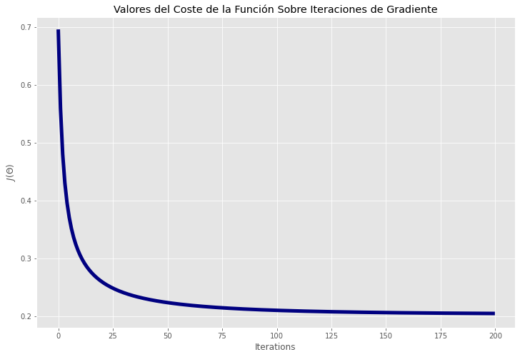

```python
ratio_aprendizaje = 1
n_iteraciones = 200
X = np.append(np.ones((rows, 1)), scores, axis=1)
y = results.reshape(rows, 1)
theta_init = np.zeros((cols + 1, 1))
theta, costs = gradient_descent(X, y, theta_init, ratio_aprendizaje, n_iteraciones)

plt.plot(costs, color= 'navy',linewidth=5)
plt.xlabel("Iterations")
plt.ylabel("$J(\Theta)$")
plt.title("Valores del Coste de la Función Sobre Iteraciones de Gradiente");
```

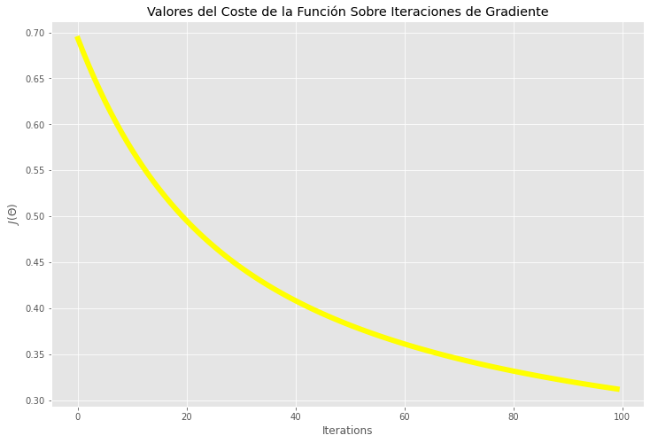

```python
ratio_aprendizaje = 0.1
n_iteraciones = 100
X = np.append(np.ones((rows, 1)), scores, axis=1)
y = results.reshape(rows, 1)
theta_init = np.zeros((cols + 1, 1))
theta, costs = gradient_descent(X, y, theta_init, ratio_aprendizaje, n_iteraciones)

plt.plot(costs, color= 'yellow' ,linewidth=6)
plt.xlabel("Iterations")
plt.ylabel("$J(\Theta)$")
plt.title("Valores del Coste de la Función Sobre Iteraciones de Gradiente");
```

Con cada iteración de gradiente observamos que el coste desciende.

## Referencias

Towards Data Science : https://towardsdatascience.com/gradient-descent-in-python-a0d07285742f

Implement Gradient Desecent: https://towardsdatascience.com/implement-gradient-descent-in-python-9b93ed7108d1